# Legends

Author

Jaeson

## 1 Basic Box Plot

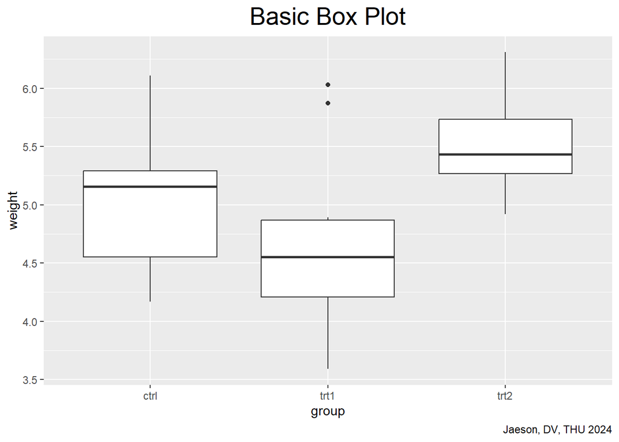

```r
library(ggplot2)

ggplot(PlantGrowth, aes(x = group, y = weight)) +
  geom_boxplot() +
labs(title="Basic Box Plot",
       x = "group", y = "weight",
       caption = 'Jaeson, DV, THU 2024')+
  theme(plot.title = element_text(hjust = 0.5, size=20))
```

## 2 Add Legend

- `library(gridExtra)`: This loads the `gridExtra` package in R, which provides functions to arrange multiple plots in a grid layout.
- `fill`: In plotting or layout contexts, `fill` is an argument used to set the background color or fill color of elements.
- `color`: In plotting, `color` specifies the outline or border color of elements, like points, lines, or shapes.
- `grid.arrange`: A function from the `gridExtra` package used to arrange multiple plots or grobs in a grid layout.
- `top`: An argument in `grid.arrange` used to add a title to the top of the arranged grid.
- `bottom`: An argument in `grid.arrange` used to add a caption or annotation to the bottom of the arranged grid. By adding `fill` or `color` options to `aes()`, a legend is created automatically on the right side of the plot.

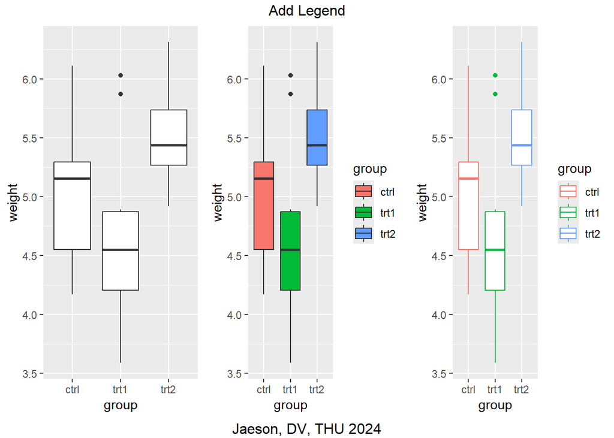

```r
library(gridExtra)

p1 <- ggplot(PlantGrowth, aes(x = group, y = weight)) +
  geom_boxplot()
p2 <- ggplot(PlantGrowth, aes(x = group, y = weight, fill = group)) +
  geom_boxplot()
p3 <- ggplot(PlantGrowth, aes(x = group, y = weight, color = group)) +
  geom_boxplot()
grid.arrange(p1,p2,p3,ncol=3,top='Add Legend', bottom = 'Jaeson, DV, THU 2024')
```

## 3 Remove Legend

- The legend is removed by `guides(fill = FALSE)`

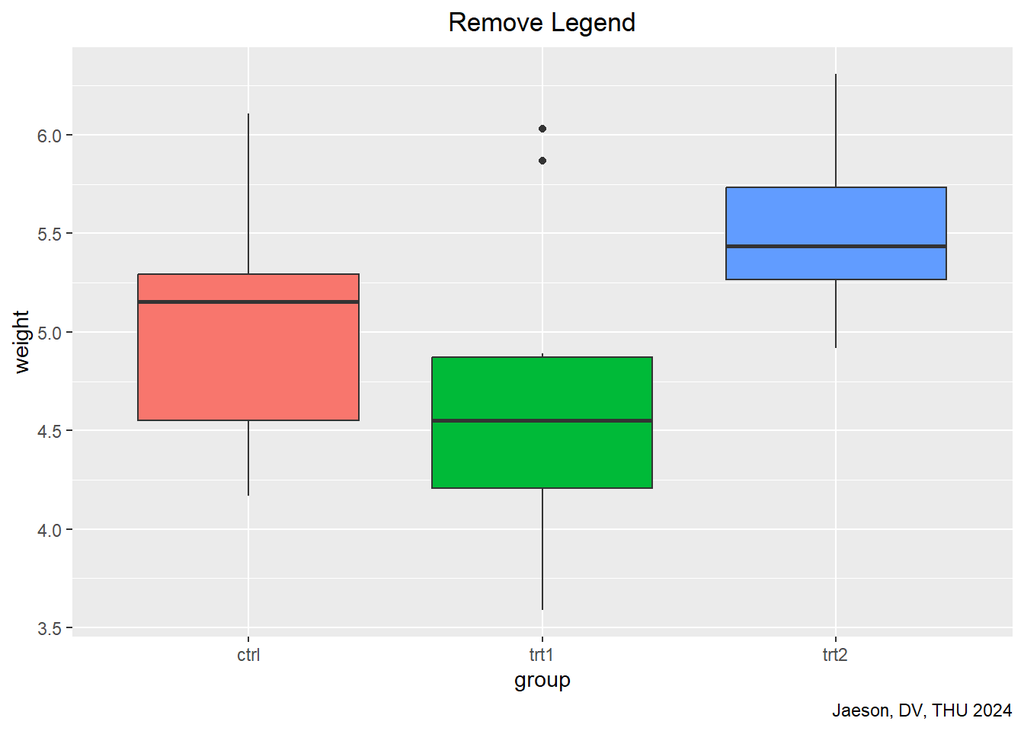

```r
ggplot(PlantGrowth, aes(x = group, y = weight, fill = group)) +
  geom_boxplot() +
  guides(fill = FALSE) +
  ggtitle('Remove Legend') +
  theme(plot.title = element_text(hjust=0.5))+
  labs(caption = 'Jaeson, DV, THU 2024')
```

## 4 Change Color of Legend

- `scale_fill_brewer`: Changes the color palette of the legend to “Pastel2”

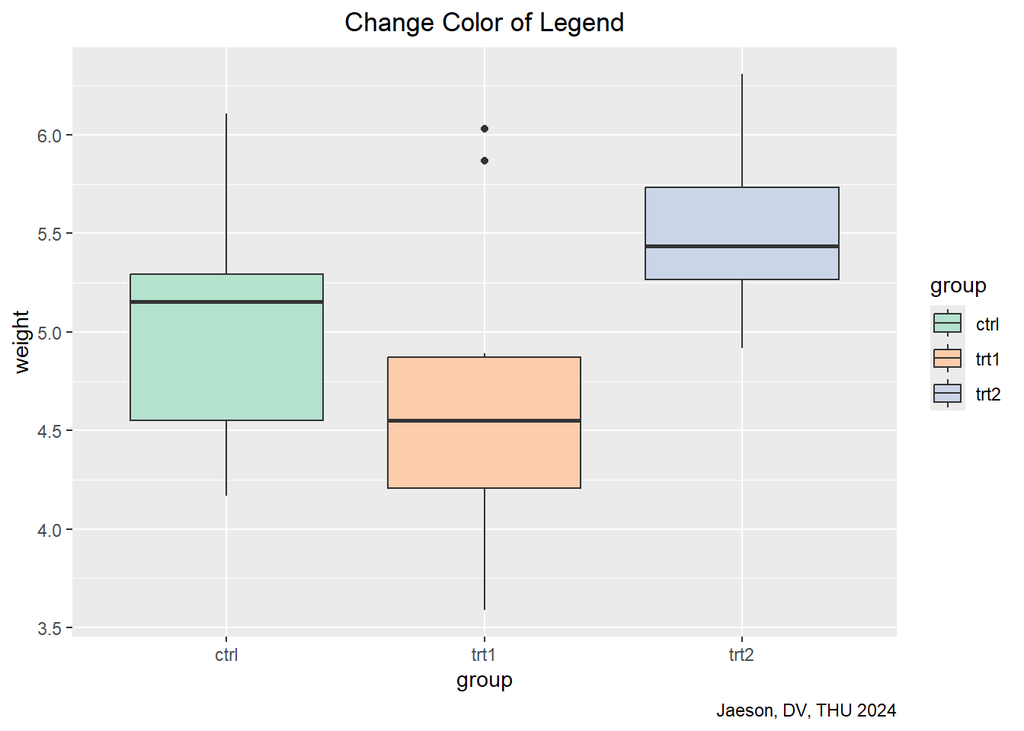

```r
ggplot(PlantGrowth, aes(x = group, y = weight, fill = group)) +
  geom_boxplot() +
  scale_fill_brewer(palette = "Pastel2") +
  ggtitle('Change Color of Legend') +
  theme(plot.title = element_text(hjust=0.5))+
  labs(caption = 'Jaeson, DV, THU 2024')
```

## 5 Change Position of Legend

- `theme(legend.position = 'top')`: Moves the legend position to the top of the plot.

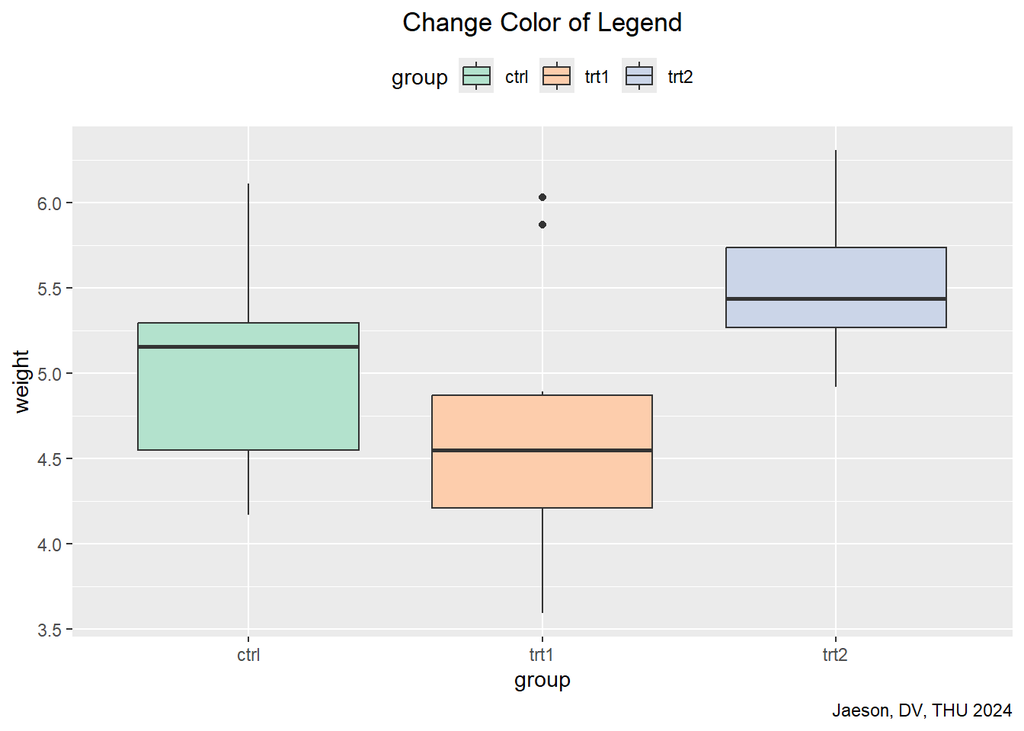

```r
ggplot(PlantGrowth, aes(x = group, y = weight, fill = group)) +
  geom_boxplot() +
  scale_fill_brewer(palette = "Pastel2") +
  ggtitle('Change Color of Legend') +
  theme(plot.title = element_text(hjust=0.5),
        legend.position = 'top')+
  labs(caption = 'Jaeson, DV, THU 2024')
```

## 6 Practise

Change legend position to top, bottom, left, and right.

- `bottom`: Places the legend below the plot.
- `left`: Places the legend to the left of the plot.
- `right`: Places the legend to the right of the plot.

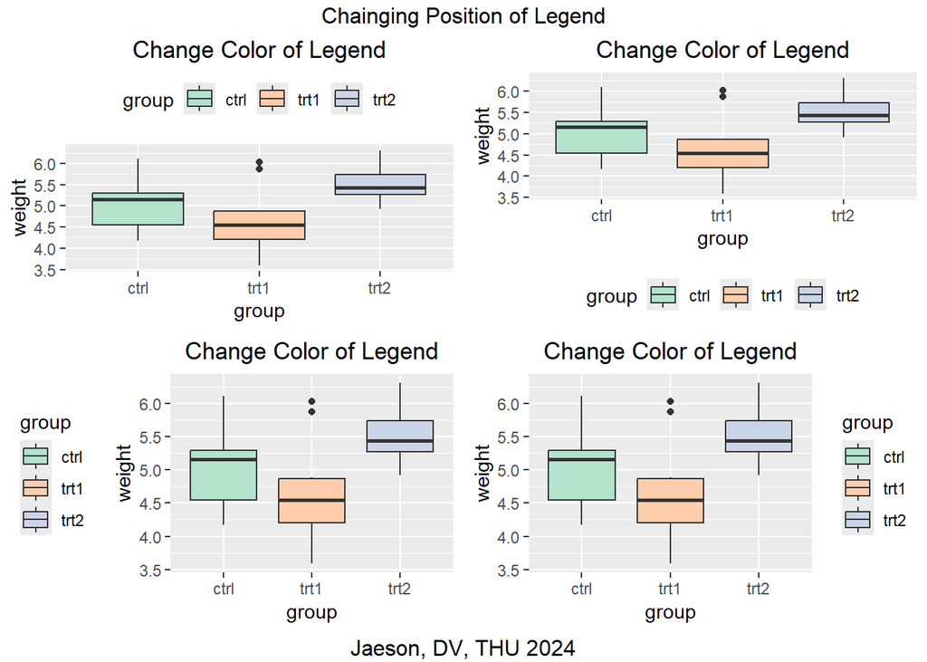

```r
p1 <- ggplot(PlantGrowth, aes(x = group, y = weight, fill = group)) +
  geom_boxplot() +
  scale_fill_brewer(palette = "Pastel2") +
  ggtitle('Change Color of Legend') +
  theme(plot.title = element_text(hjust=0.5),
        legend.position = 'top')
p2 <- p1 + theme(legend.position = 'bottom')
p3 <- p1 + theme(legend.position = 'left')
p4 <- p1 + theme(legend.position = 'right')

grid.arrange(p1, p2, p3, p4, ncol=2,
             top='Chainging Position of Legend', bottom = 'Jaeson, DV, THU 2024')
```

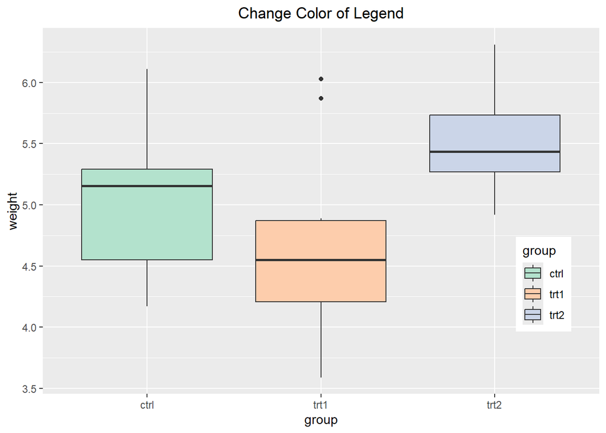

```r
ggplot(PlantGrowth, aes(x = group, y = weight, fill = group)) +
  geom_boxplot() +
  scale_fill_brewer(palette = "Pastel2") +
  ggtitle('Change Color of Legend') +
  theme(plot.title = element_text(hjust=0.5),
        legend.position = c(.9, .3))
```

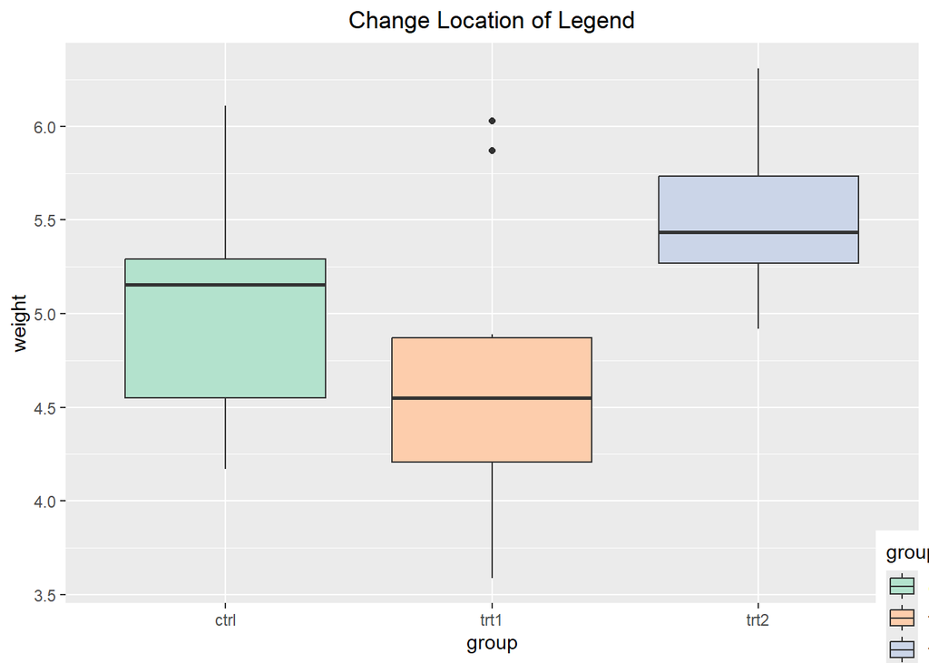

```r
ggplot(PlantGrowth, aes(x = group, y = weight, fill = group)) +
  geom_boxplot() +
  scale_fill_brewer(palette = "Pastel2") +
  ggtitle('Change Location of Legend') +
  theme(plot.title = element_text(hjust=0.5),
        legend.position = c(1, 0))
```

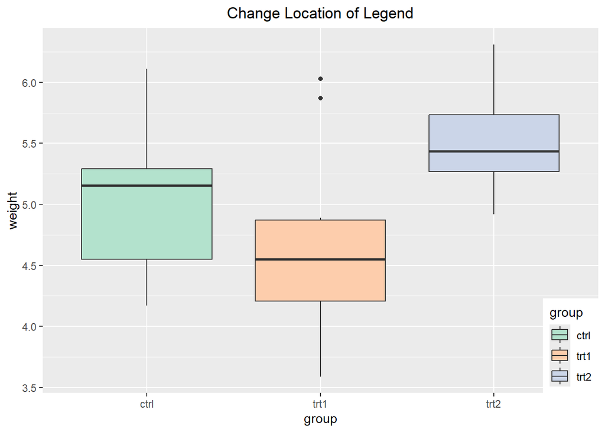

```r
ggplot(PlantGrowth, aes(x = group, y = weight, fill = group)) +
  geom_boxplot() +
  scale_fill_brewer(palette = "Pastel2") +
  ggtitle('Change Location of Legend') +
  theme(plot.title = element_text(hjust=0.5),
        legend.position = c(1, 0),
        legend.justification = c(1, 0))
```

## 8 Change Border of Legend

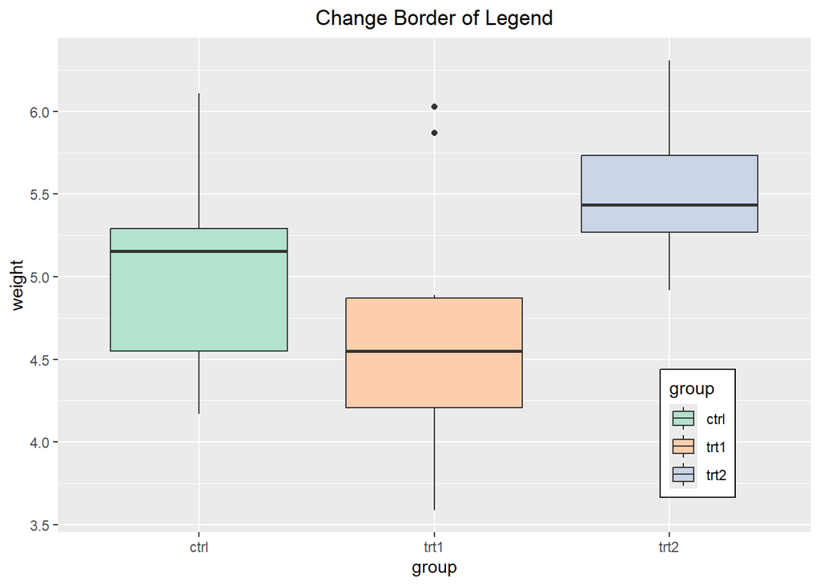

```r
ggplot(PlantGrowth, aes(x = group, y = weight, fill = group)) +
  geom_boxplot() +
  scale_fill_brewer(palette = "Pastel2") +
  ggtitle('Change Border of Legend') +
  theme(plot.title = element_text(hjust=0.5),
        legend.position = c(0.85, 0.2),
        legend.background = element_rect(fill = 'white',
                                         color = 'black'))
```

## 9 Change Background of Legend

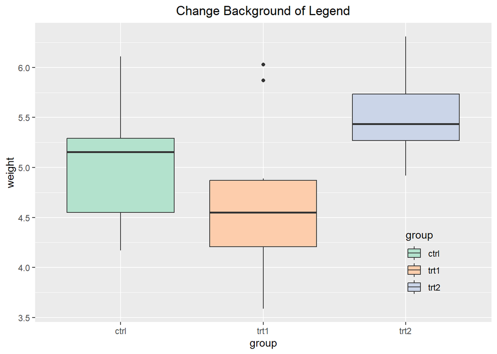

```r
ggplot(PlantGrowth, aes(x = group, y = weight, fill = group)) +
  geom_boxplot() +
  scale_fill_brewer(palette = "Pastel2") +
  ggtitle('Change Background of Legend') +
  theme(plot.title = element_text(hjust=0.5),
        legend.position = c(0.85, 0.2),
        legend.background = element_blank(),
        legend.key = element_blank())
```

## 10 Change Order of Items in Legend

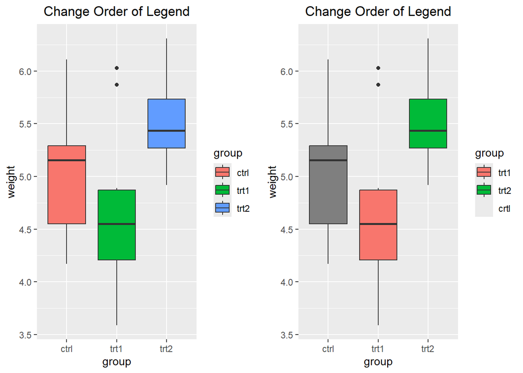

```r
p1 <- ggplot(PlantGrowth, aes(x = group, y = weight, fill = group)) +
  geom_boxplot() +
  ggtitle('Change Order of Legend') +
  theme(plot.title = element_text(hjust=0.5))

p2 <- p1 + scale_fill_discrete(limits = c('trt1', 'trt2', 'crtl'))

grid.arrange(p1, p2, ncol = 2)
```

## 11 Reverse Order of Items in Legend

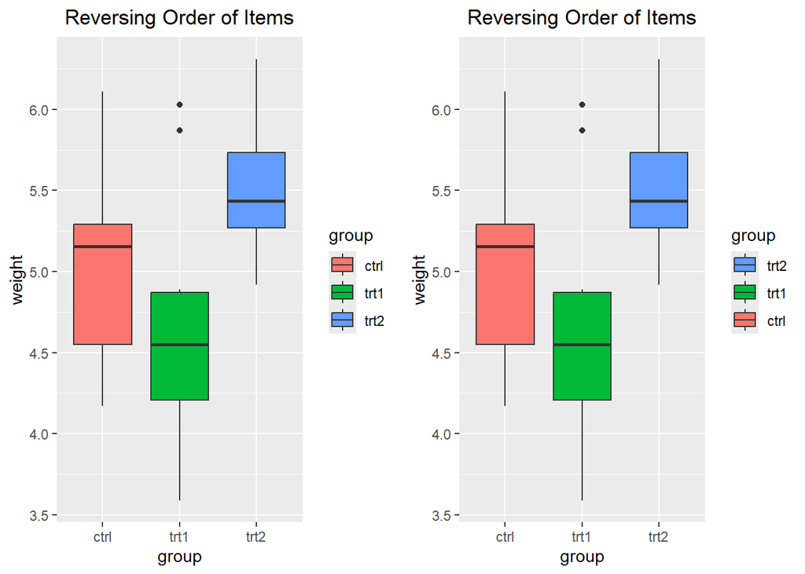

```r
p1 <- ggplot(PlantGrowth, aes(x = group, y = weight, fill = group)) +
  geom_boxplot() +
  ggtitle('Reversing Order of Items') +
  theme(plot.title = element_text(hjust=0.5))

p2 <- p1 + guides(fill = guide_legend(reverse = TRUE))

grid.arrange(p1, p2, ncol = 2)
```

## 12 Change Legend Title

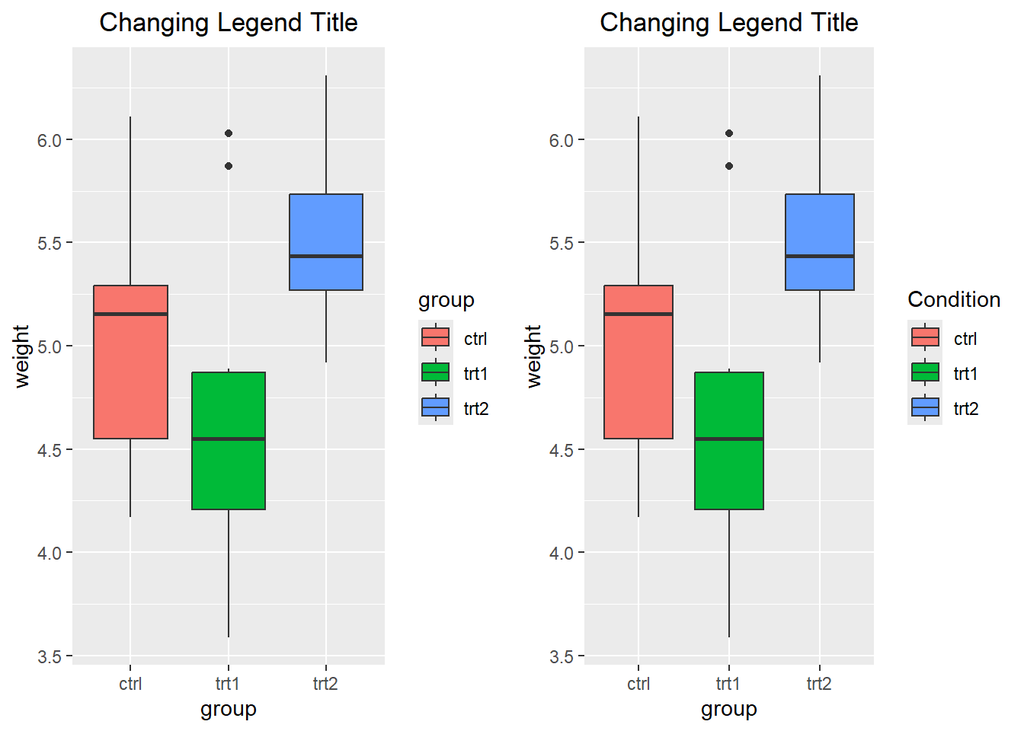

```r
p1 <- ggplot(PlantGrowth, aes(x = group, y = weight, fill = group)) +
  geom_boxplot() +
  ggtitle('Changing Legend Title') +
  theme(plot.title = element_text(hjust=0.5))

p2 <- p1 + labs(fill = 'Condition')

grid.arrange(p1, p2, ncol = 2)
```

## 13 Change Appearance of Legend Title

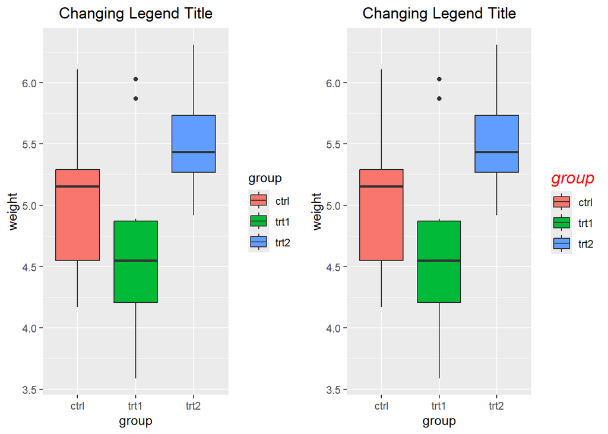

```r
p1 <- ggplot(PlantGrowth, aes(x = group, y = weight, fill = group)) +
  geom_boxplot() +
  ggtitle('Changing Legend Title') +
  theme(plot.title = element_text(hjust=0.5))

p2 <- p1 + theme(legend.title = element_text(face = 'italic',
                                             family = 'Times',
                                             color = 'red',
                                             size = 14))
grid.arrange(p1, p2, ncol = 2)
```

## 14 Remove Legend Title

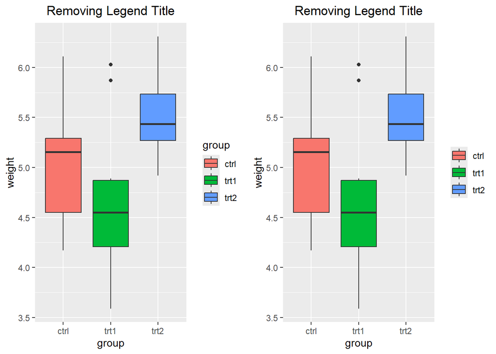

```r
p1 <- ggplot(PlantGrowth, aes(x = group, y = weight, fill = group)) +
  geom_boxplot() +
  ggtitle('Removing Legend Title') +
  theme(plot.title = element_text(hjust=0.5))

p2 <- p1 + guides(fill = guide_legend(title = NULL))

grid.arrange(p1, p2, ncol = 2)
```

## 15 Change Labels in Legend

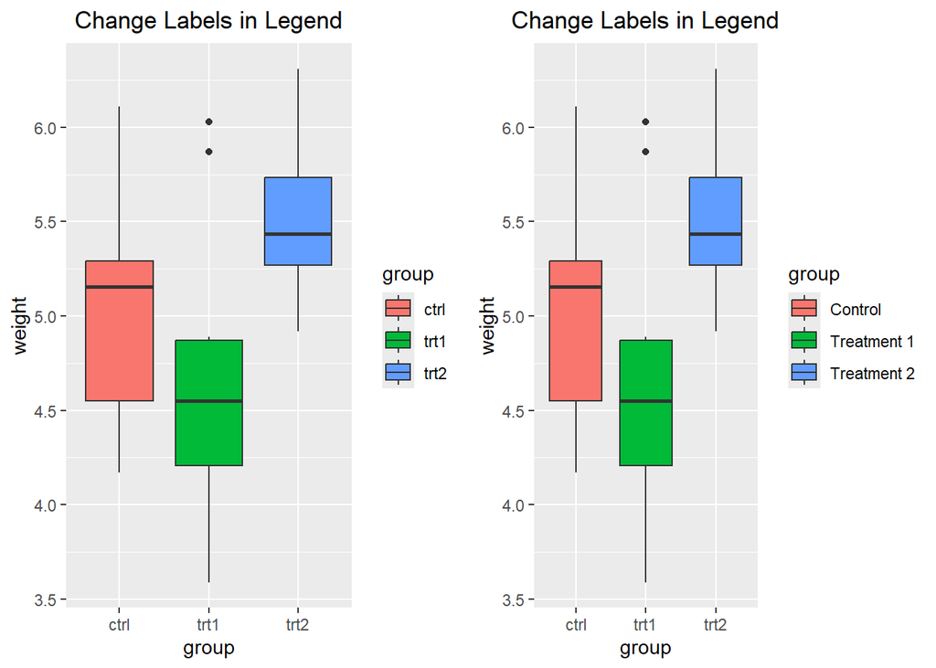

```r
p1 <- ggplot(PlantGrowth, aes(x = group, y = weight, fill = group)) +
  geom_boxplot() +
  ggtitle('Change Labels in Legend') +
  theme(plot.title = element_text(hjust=0.5))

p2 <- p1 +
  scale_fill_discrete(labels = c('Control',
                                 'Treatment 1',
                                 'Treatment 2'))

grid.arrange(p1, p2, ncol = 2)
```